# Data Visualization Homework Assignment 4

Student’s Name: Chutian Zhou UNI: cz2482

April 9, 2018

In this write-up, I will include code chunks[^1], results as well as my short inpretations.

## 0. Housekeeping Stuff

```r
#Read essential packages
library(igraph)
library(dplyr)
library(networkD3)
library(DT)
library(widgetframe)
library(ggnetwork)
library(ggplot2)
library(network)
library(ggrepel)
library(tidyr)
library(lubridate)
library(stringr)
```

## 1. Who follows whom?

### a) Network of Followers

I subset the original data frame first, as the homework guidelines have required in the beginning. The key step after this is creating a graph object using the `graph_from_data_frame` function from the `igraph` package.

```r
#read files
follow<-read.csv("C:/Columbia/2018Spring/DataVisualization/HW4/senators_follow.csv")
twitter<-read.csv("C:/Columbia/2018Spring/DataVisualization/HW4/senators_twitter.csv")

#subset follow df
follow$following<-as.character(follow$following)
follow<-subset(follow,following=="TRUE")

#as_data_frame
follow<-dplyr::as_data_frame(follow)

#create a graph object
follow_gr<-graph_from_data_frame(follow[,c("source", "target")],directed=T)
```

Then things become easy. The `igraph:degree` function is able to calculate the in-degree and out-degree centrality. The following two chunks return the results.

```r
#identify three senators who have highest in-degree and out-degree
indegree=igraph::degree(follow_gr,mode="in")
sort(indegree,decreasing=T)
```

```
##  SenJeffMerkley  SenJohnKennedy       SenMarkey      MarkWarner
##              96              95              95              95
##     SenatorEnzi       MikeCrapo   SenDeanHeller SenSherrodBrown
##              94              93              93              93
##   SenatorHassan     SenBobCasey SenatorTimScott   lisamurkowski
##              92              92              90              89
##  sendavidperdue   SenatorCardin   SenThomTillis    amyklobuchar
##              89              88              88              87
##      CoryBooker     SenBennetCO  SenatorFischer  SenatorBaldwin
##              87              86              86              86
##  SenCortezMasto      JohnCornyn    SenAngusKing SenatorTomUdall
##              85              84              83              82
## SenatorLankford   SenatorRounds  Sen_JoeManchin   SenatorTester
##              81              81              81              79
##      ChrisCoons    SenDuckworth   SenatorCarper  SenatorCollins
##              77              77              76              76
##     SenatorBurr   SenGaryPeters   senrobportman     PattyMurray
##              75              72              71              71
##  SenDanSullivan    SenFeinstein   SenatorDurbin       SenToomey
##              70              70              70              70
##      SenMikeLee SenatorMenendez   SenJohnHoeven   SenWhitehouse
##              70              67              67              67
##       SenWarren        RonWyden   SenBlumenthal     maziehirono
##              65              63              60              60
##      JerryMoran   SenPatRoberts  SenatorShaheen      SenSchumer
##              60              59              59              58
##  MartinHeinrich       SenShelby     SenStabenow        RoyBlunt
##              56              52              51              51
## SenJohnBarrasso  SenatorIsakson SenatorCantwell   SenRonJohnson
##              51              50              49              49
##     SteveDaines    SenateMajLdr    SenTinaSmith      SenTedCruz
##              48              47              47              47
##  ChrisVanHollen   SenGillibrand  SenThadCochran SenKamalaHarris
##              46              46              45              44
##    SenatorRisch     JohnBoozman  SenCoryGardner    SenTomCotton
##              44              42              42              41
##     brianschatz   SenatorWicker    SenDougJones        RandPaul
##              40              40              39              39
##    SenAlexander    SenatorLeahy SenatorHeitkamp      GrahamBlog
##              37              36              33              30
##        timkaine       SenCapito    SenJohnThune   ChuckGrassley
##              29              28              26              25
##   senorrinhatch   SenJohnMcCain     SenJackReed    SenToddYoung
##              23              18              18              16
##   ChrisMurphyCT       JimInhofe     BillCassidy     SenDonnelly
##              14              13              12              11
##       BobCorker        BenSasse       JeffFlake      marcorubio
##              11              10               7               1
##       joniernst       clairecmc   SenBillNelson
##               1               1               0
```

```r
outdegree=igraph::degree(follow_gr,mode="out")
sort(outdegree,decreasing=T)
```

```
##  SenatorCollins   SenJohnMcCain   lisamurkowski     SenatorBurr
##              82              78              76              72
## SenJohnBarrasso        RoyBlunt   SenDeanHeller       SenToomey
##              72              71              71              71
##   ChuckGrassley   senrobportman  Sen_JoeManchin       MikeCrapo
##              70              70              70              69
##      JohnCornyn   SenJohnHoeven    SenAlexander   SenRonJohnson
##              68              67              67              67
##  SenatorIsakson      JerryMoran   SenatorWicker      GrahamBlog
##              66              66              66              66
## SenatorTimScott      MarkWarner    SenAngusKing    SenJohnThune
##              66              66              65              65
##     SenatorEnzi     SenDonnelly   SenPatRoberts       JeffFlake
##              65              64              64              63
##     JohnBoozman   SenBlumenthal  SenThadCochran  SenatorFischer
##              63              63              63              63
##      CoryBooker SenatorHeitkamp   SenatorCarper   SenatorDurbin
##              63              63              62              62
##     SenStabenow SenatorTomUdall      SenSchumer        RonWyden
##              62              62              62              62
##     SenBobCasey     SenBennetCO      ChrisCoons    SenatorRisch
##              62              61              61              61
##   SenatorCardin   SenWhitehouse      SenMikeLee    SenatorLeahy
##              61              61              61              61
##       SenShelby     maziehirono        RandPaul SenatorMenendez
##              60              60              60              60
## SenSherrodBrown  SenJeffMerkley   senorrinhatch     PattyMurray
##              60              60              60              60
##  SenatorShaheen     SenJackReed        timkaine    SenFeinstein
##              59              59              58              57
##      marcorubio       clairecmc  MartinHeinrich   SenBillNelson
##              57              57              57              56
##  sendavidperdue  SenatorBaldwin   SenGillibrand   SenThomTillis
##              56              56              55              55
## SenatorCantwell       SenWarren   SenGaryPeters   ChrisMurphyCT
##              55              54              54              53
## SenatorLankford  SenCoryGardner   SenatorTester       SenCapito
##              53              52              52              51
##    amyklobuchar    SenTomCotton   SenatorRounds    SenateMajLdr
##              50              49              49              48
##       SenMarkey       JimInhofe      SenTedCruz  SenDanSullivan
##              48              48              48              47
##     SteveDaines    SenDuckworth   SenatorHassan  ChrisVanHollen
##              47              39              39              37
##     brianschatz     BillCassidy  SenCortezMasto  SenJohnKennedy
##              35              35              35              33
##    SenDougJones    SenTinaSmith        BenSasse    SenToddYoung
##              32              32              32              30
## SenKamalaHarris       joniernst       BobCorker
##              29              15               1
```

In terms of the in-degree centrality, Jeff Merkley, John Kennedy, Ed Markey, Mark Warner and Mike Enzi have the highest scores (96, 95, 95, 95 and 94, separately). On the other hand, Susan Collins, John McCain and Lisa Murkowski have the highest out-degree centrality (82, 78 and 76, separately).

Finally, the codes below draw the network graph. Notice that before the procedure of importing senators’ party affiliation information for the purpose of coloring the nodes by party, I have replaced the names “SenMarkey” and “sendavidperdue” with “senmarkey” and “SenDavidPerdue” instead so that they match the displays in the file `senators_twitter.csv`.

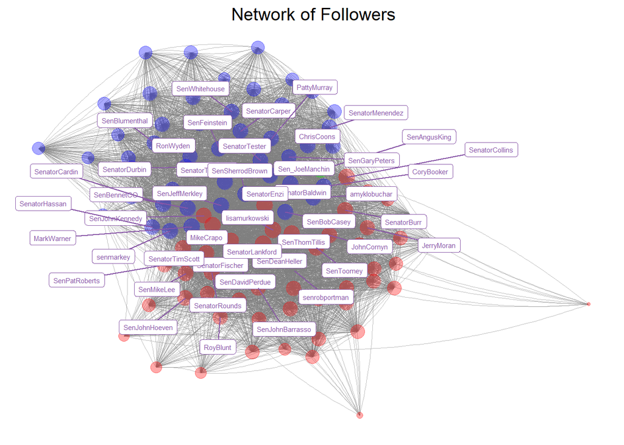

```r
#generate "size"
V(follow_gr)$size<-centralization.degree(follow_gr)$res

#simplify
E(follow_gr)$weight <- 1
follow_g<-simplify(follow_gr,edge.attr.comb="sum")

#fortify
set.seed(2103)
data<-ggnetwork(follow_g,layout="fruchtermanreingold",
          arrow.gap=0,cell.jitter=0)

#let senators have their party affiliations
acc_aff<-twitter[,c("Official.Twitter","Party.affiliation")]
acc_aff$Official.Twitter<-as.character(acc_aff$Official.Twitter)
acc_aff$Party.affiliation<-as.character(acc_aff$Party.affiliation)

#edit problematic names and import party information
data$vertex.names<-as.character(data$vertex.names)
data$vertex.names<-replace(data$vertex.names,
                             data$vertex.names=="SenMarkey","senmarkey")
data$vertex.names<-replace(data$vertex.names,
                             data$vertex.names=="sendavidperdue","SenDavidPerdue")
data$x<-as.numeric(data$x)
data$y<-as.numeric(data$y)
data$xend<-as.numeric(data$xend)
data$yend<-as.numeric(data$yend)
data<-data%>%left_join(acc_aff,by=c("vertex.names"="Official.Twitter"))
data$Party.affiliation<-as.factor(data$Party.affiliation)

#draw graph
ggplot()+
  geom_edges(data=data,
             aes(x=x,y=y,xend=xend,yend=yend),
             color="grey50",curvature=0.1,size=0.15,alpha=1/2)+
  geom_nodes(data=data,
             aes(x=x, y=y,xend=xend,yend=yend,color=Party.affiliation,
                 size=sqrt(size)),alpha=1/3)+
  geom_label_repel(data=unique(data[data$size>120,c(1,2,5)]),
                   aes(x=x,y=y,label=vertex.names),
                   size=2,color="#8856a7")+
  theme_blank()+
  theme(legend.position="none")+
  ggtitle("Network of Followers")+
  theme(plot.title=element_text(hjust=0.5))+
  scale_color_manual(breaks=c("Democratic Party","Republican Party","Independent"),
                     values=c("blue","green","red"))
```

Blue nodes indicate Democrats whereas red ones denote Republicans. All the nodes are sized according to degree centrality. The network graph is complex, but an explicit phenomenon is that all links that connect nodes are twisted, meaning that senators generally follow each other despite their distinct party affiliations. Interestingly, there are two Republican senators who are weakly connected with the community, for they are at the edge of the whole graph.

### b) Communities

I have drawn a force directed network plot for this question.[^2]

```r
#find "communities"
wc2<-cluster_walktrap(follow_g)
members2<-membership(wc2)

#Convert igraph object to object suitable for networkD3
follow_d3<-igraph_to_networkD3(follow_g,group=members2)

#draw graph
forceNetwork(Links=follow_d3$links,Nodes=follow_d3$nodes,
                    Source='source', Target='target',
                    NodeID='name', Group='group')
```

[interactive chart not shown]

The graph is sort of much messier than the one in Question 1(a), since this is a three-dimensional interactivity plot. It is not very informative (yet I do not see any errors in my codes because I followed professor’s `clinton_emails_slides.rmd` strictly). In any case, I think this method is able to recover the party affiliation of senators.

## 2. What are they Tweeting about?

### a) Most Common Topics over Time

For Question 2(a), I draw a bar plot of the most frequently used hashtags.

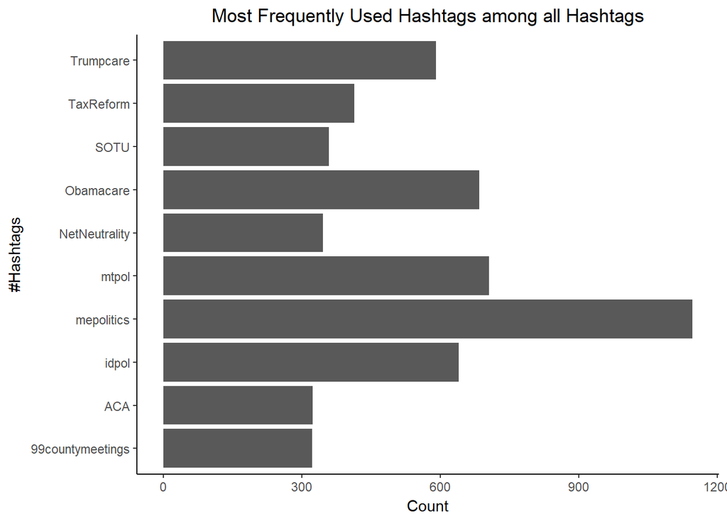

```r
#read file
tweets<-readRDS("C:/Columbia/2018Spring/DataVisualization/HW4/senator_tweets.rds")
tweets<- dplyr::as_data_frame(tweets)

#retain obs that are not retweets
tweets_a<-tweets%>%filter(is_retweet=="FALSE")

#variable "hashtags" is a list
tweets_a$hashtags<-as.character(tweets_a$hashtags)

#retain hashtags column only
tweets_a<-tweets_a[,"hashtags"]

#calculate frequencies
tweets_a<-tweets_a%>%group_by(hashtags)%>%summarise(count=n())%>%arrange(desc(count))

#remove "NA"
tweets_a<-tweets_a[-1,]

#retain the first 10 rows
tweets_a<-tweets_a[1:10,]

#draw graph
ggplot(tweets_a,aes(hashtags,count))+
  stat_summary(fun.y=mean,geom="bar")+
  coord_flip()+
  theme_classic()+
  ggtitle("Most Frequently Used Hashtags among all Hashtags")+
  theme(plot.title=element_text(hjust=0.5))+
  ylab("Count")+xlab("#Hashtags")
```

According to the figure, “mepolitics” is the most common hashtag, which has been used by almost 1,200 times. The second and the third ranking hashtags are “mtpol” and “Obamacare.”

### b) Democrats vs. Republicans

For Question 2(b) only, I retained all observations (i.e. tweets) that are created in the year of 2018 and dropped those that are not. This gives me 17,391 observations. The graph below shows how senators from two parties differ on the choice of topics.

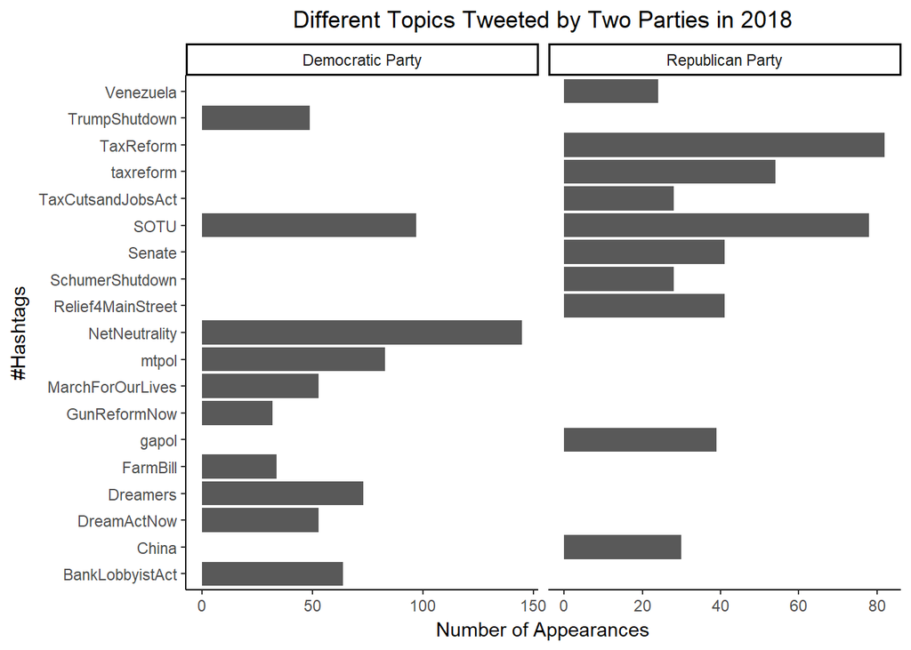

```r
#remain obs that are in year 2018
tweets_b<-tweets%>%filter(created_at>=as.Date("2018-01-01"))
tweets_b<-tweets_b[,c("screen_name","hashtags")]

#variable "hashtags" is a list
tweets_b$hashtags<-as.character(tweets_b$hashtags)

#senmarkey and sendavidperdue "capitalize problem"
tweets_b$screen_name<-replace(tweets_b$screen_name,
                              tweets_b$screen_name=="SenMarkey","senmarkey")
tweets_b$screen_name<-replace(tweets_b$screen_name,
                              tweets_b$screen_name=="sendavidperdue","SenDavidPerdue")

#import party affiliation data
tweets_b<-tweets_b%>%left_join(acc_aff,by=c("screen_name"="Official.Twitter"))

#dataset transformation
tweets_b<-tweets_b%>%group_by(hashtags,Party.affiliation)%>%
  summarise(count=n())%>%arrange(desc(count))

#remove NA rows
tweets_b<-tweets_b[-c(1,2,4),]

#retain top10 D and top10 R in terms of "count"
tweets_b<-tweets_b[c(1,2,3,6,7,9,10,11,15,16,4,5,8,12,13,14,18,21,22,29),]

#draw graph
ggplot(tweets_b,aes(hashtags,count))+
  stat_summary(fun.y=mean,geom="bar")+
  facet_wrap(~Party.affiliation,scales="free_x")+coord_flip()+
  theme_classic()+
  ggtitle("Different Topics Tweeted by Two Parties in 2018")+
  theme(plot.title=element_text(hjust=0.5))+
  ylab("Number of Appearances")+xlab("#Hashtags")
```

According to the figure, top 3 topics for Democrats in 2018 are “NetNeutrality,” “SOTU” and “mtpol,” while top 3 topics for Republicans are “TaxReform,” “SOTU” and “taxreform.”

It is interesting to note that two parties have salient tendencies. For example, senators of the opposition party, Democratic Party, frequently post tweets relative to “TrumpShutdown” to express their dissatisfactions. In contrast, Republicans barely say anything bad about Trump, but will attack Schumer from the Democratic Party instead.

### c) Gun Control I - Dems vs. Reps

For Question 2(c), I only retain observations whose hashtags are “gunsafety”, “GunReform”, “Enough”, “NRA”, “2ndamendment”, “NRAAM” and “2A.” The first three hashtags are likely to be used by gun control supporters (i.e. Democrats), and the last four are probably preferred by gun rights supporters (i.e. Republicans). The dataset size under the constraint of this filter rule is relatively small; there are only 58 observations. Yet, this does not affect my storytelling, as you will see from the figure below.

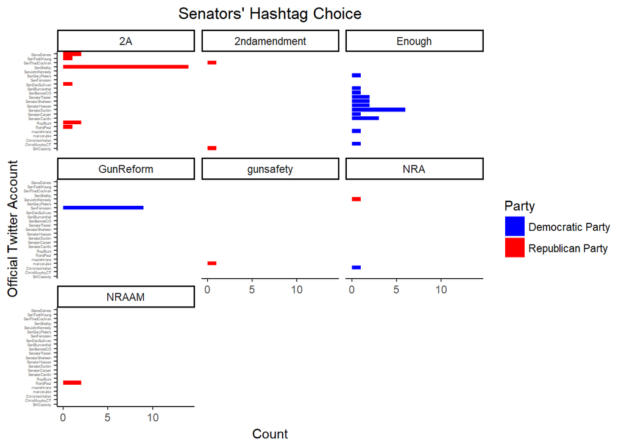

```r
tweets$hashtags<-as.character(tweets$hashtags)

#create target
target<-c("gunsafety","GunReform","Enough",
          "NRA","2ndamendment","NRAAM","2A")

#filter
tweets_c<-tweets%>%filter(hashtags%in%target)

#retain screen_name and hashtags only
tweets_c<-tweets_c[,c("screen_name","hashtags")]

#edit SenMarkey
tweets_c$screen_name<-replace(tweets_c$screen_name,
                              tweets_c$screen_name=="SenMarkey","senmarkey")

#import party affiliation data
tweets_c<-tweets_c%>%left_join(acc_aff,by=c("screen_name"="Official.Twitter"))

#data transformation
tweets_c_data<-tweets_c%>%
  group_by(hashtags,screen_name,Party.affiliation)%>%
  summarise(count=n())

#change column name of "Party.affiliation"
colnames(tweets_c_data)[3]<-"Party"

#draw graph
ggplot(tweets_c_data,aes(screen_name,count),group=Party)+
  stat_summary(fun.y=mean,geom="bar",aes(y=count,fill=Party))+
  facet_wrap(~hashtags)+
  theme_classic()+coord_flip()+
  ggtitle("Senators' Hashtag Choice")+
  theme(plot.title=element_text(hjust=0.5))+
  ylab("Count")+xlab("Official Twitter Account")+
  theme(axis.text.y=element_text(angle=0, hjust=1,size=3))+
  scale_fill_manual(breaks=c("Democratic Party","Republican Party"),
                    values=c("blue","red"))
```

The whole graph is faceted by 7 sub-graphs; each is pointed to a specific topic. The colors of bars are set by groups (i.e. Democratic Party as blue, Republican Party as red). What this figure shows unsurprisingly fits my expectation; Democrats frequently tweet on “Enough” and “GunReform,” while Republicans tweet more on “2A,” “2ndamendment” and “NRAAM.” Two parties have paid equal attention to “NRA.”

### d) Gun Control II - Parkland Shooting

For Question 2(d), I choose to draw a word cloud to plot senators’ responses to the shooting.

First of all, I filter for observations that only have the word “Parkland” in the *text* column. Then, I use the `clean_corpus` function and the `stemCompletion2` function introduced by professor in previous lectures to clean the corpus, and perform word stemming and stem completion. Finally, I draw the word cloud based on the term frequency (TF)-inverse document frequency (IDF).

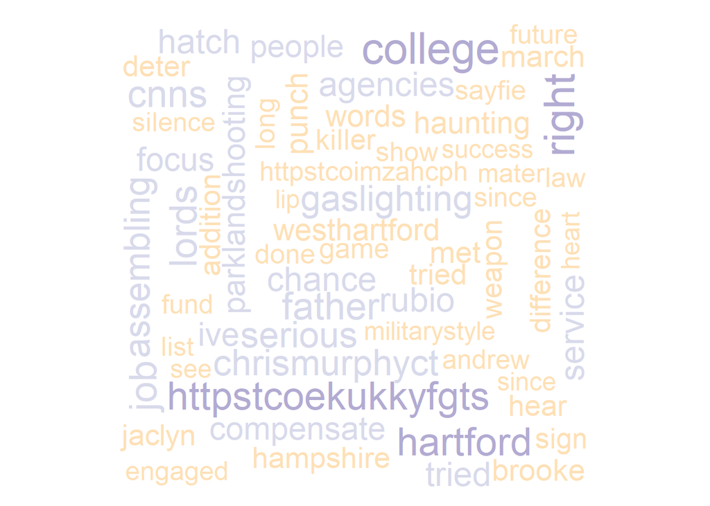

```r
#read packages
library(tm)
library(wordcloud)
library(qdap)
library(tidytext)
library(parallel)

#filter for obs that only have "Parkland" in the "text" column
tweets_d<-tweets%>%filter(grepl('Parkland',text))
tweets_d<-tweets_d[,c("text","status_id")]
tweets_d$status_id<-as.numeric(tweets_d$status_id)
colnames(tweets_d)[2]<-"doc_id"

tweets_d_source<-DataframeSource(tweets_d)
tweets_d_corpus<-VCorpus(tweets_d_source)

#cleaning function
removeNumPunct<-function(x){gsub("[^[:alpha:][:space:]]*", "", x)}
clean_corpus<-function(corpus){
  corpus<-tm_map(corpus, removePunctuation)
  corpus<-tm_map(corpus, content_transformer(tolower))
  corpus<-tm_map(corpus, content_transformer(replace_symbol))
  corpus<-tm_map(corpus, removeWords, c(stopwords("en")))
  corpus<-tm_map(corpus, removeNumbers)
  corpus<-tm_map(corpus, content_transformer(removeNumPunct))
  corpus<-tm_map(corpus, stripWhitespace)
  return(corpus)
}

#use clean_corpus function to clean tweets_d_corpus
tweets_d_corpus_clean<-clean_corpus(tweets_d_corpus)

#stemming tweets_d_corpus_clean
tweets_d_stemmed<-tm_map(tweets_d_corpus_clean,stemDocument)

#stemcompletion
stemCompletion2<-function(x,dictionary) {
  x<-unlist(strsplit(as.character(x), " "))
  x<-x[x != ""]
  x<-stemCompletion(x, dictionary=dictionary)
  x<-paste(x, sep="", collapse=" ")
  PlainTextDocument(stripWhitespace(x))
}

#complete tweets_d_stemmed
tweets_d_comp_all<-mclapply(tweets_d_stemmed,stemCompletion2,
                       dictionary=tweets_d_corpus_clean)

tweets_d[]<-lapply(tweets_d,as.character)

for (i in 1:dim(tweets_d)[1]){
  tweets_d_comp_all[[i]]$meta$id<-tweets_d[i,"doc_id"]
}

tweets_d_comp_all<-as.VCorpus(tweets_d_comp_all)

#make a dtm
tweets_d_dtm<-DocumentTermMatrix(tweets_d_comp_all)

#tidying tweets_d_dtm
tweets_d_td<-tidy(tweets_d_dtm)

#calculating frequencies
tweets_d_tf_idf<-tweets_d_td%>%
  bind_tf_idf(term,document,count)%>%
  arrange(desc(tf))

#draw wordcloud
purple_orange<-brewer.pal(10,"PuOr")
purple_orange<-purple_orange[-(1:2)]
set.seed(1)
wordcloud(tweets_d_tf_idf$term,tweets_d_tf_idf$tf_idf,
          max.words=500,colors=purple_orange)
```

## 3. Are You Talking to Me?

### a) Identifying Re-Tweets

First and foremost, I preserve a subset of the original data frame such that `is_retweet==TRUE` to roughly select a set of re-tweeted messages.

```r
#retain obs that are only retweets
tweets_3a<-tweets%>%filter(is_retweet=="TRUE")

#subsetting
tweets_3a<-tweets_3a[,c("screen_name","text","mentions_screen_name")]
```

Next is the key step. Senators sometimes mention a couple of persons or institutions in a single tweet, which means there might be more than one names in the *mentions_screen_name* column. Unnesting this list column–using the `unnest` function–makes tweets with several mentioned screen names appear multiple times. Most importantly, the screen name appears first among the repeitive rows is usually the “target” who receives a retweet. The next two lines of codes tend to unnest the *mentions_screen_name* column and select the first row among the repetitive ones.

```r
#unnesting
tweets_3a<-tweets_3a%>%unnest(mentions_screen_name)

#retain the first row of repetitive obs
tweets_3a<-tweets_3a[!duplicated(tweets_3a$text),]
```

More careful data manipulation is needed to get the final data frame ready. Further elaboration of the procedures will be omitted here. They can be, however, found below. Below the code chunk is the figure.

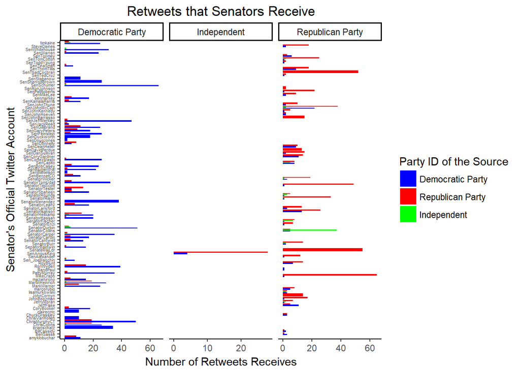

```r
#edit problematic names
tweets_3a$screen_name<-replace(tweets_3a$screen_name,
                               tweets_3a$screen_name=="SenMarkey","senmarkey")
tweets_3a$screen_name<-replace(tweets_3a$screen_name,
                             tweets_3a$screen_name=="sendavidperdue","SenDavidPerdue")
tweets_3a$mentions_screen_name<-replace(tweets_3a$mentions_screen_name,
                               tweets_3a$mentions_screen_name=="SenMarkey","senmarkey")
tweets_3a$mentions_screen_name<-replace(tweets_3a$mentions_screen_name,
                               tweets_3a$mentions_screen_name=="sendavidperdue","SenDavidPerdue")

#let sources and targets have their Party IDs
tweets_3a<-tweets_3a%>%
  inner_join(acc_aff,by=c("mentions_screen_name"="Official.Twitter"))
tweets_3a<-tweets_3a%>%
  left_join(acc_aff,by=c("screen_name"="Official.Twitter"))

#change column names
colnames(tweets_3a)[4]<-"Target.Party"
colnames(tweets_3a)[5]<-"Source.Party"

#screen_name should not be equal to mentions_screen_name
tweets_3a<-tweets_3a[which(tweets_3a[,1]!=tweets_3a[,3]),-2]

#manipulation
tweets_3a_m<-tweets_3a%>%group_by(mentions_screen_name,Source.Party)%>%summarise(count=n())

#import Party ID for mentions_screen_name
tweets_3a_m<-tweets_3a_m%>%
  left_join(acc_aff,by=c("mentions_screen_name"="Official.Twitter"))

#change column names
colnames(tweets_3a_m)[1]<-"Senator"
colnames(tweets_3a_m)[4]<-"Senator.Party"

ggplot(tweets_3a_m,aes(factor(Senator),count,fill=factor(Source.Party)))+
  geom_bar(stat="identity",position = "dodge")+coord_flip()+
  facet_wrap(~Senator.Party,scales="free_x")+
  theme_classic()+xlab("Senator's Official Twitter Account")+
  ylab("Number of Retweets Receives")+
  ggtitle("Retweets that Senators Receive")+
  theme(plot.title=element_text(hjust=0.5))+
  theme(axis.text.y=element_text(angle=0, hjust=1,size=4))+
  scale_fill_manual(breaks = c("Democratic Party", "Republican Party","Independent"),
                     values=c("blue","green","red"))+
  guides(fill=guide_legend(title="Party ID of the Source"))
```

The plot seems to be a little bit complicated, so I will spend some time describing it. Almost all of the twitter accounts are listed next to the x axis. “Democratic Party,” “Independent” and “Republican Party” below the figure title are the party affiliations of the senators. The legend also shows three colors: blue as Democrats, red as Republicans and green as Independents. They indicate the party IDs of the **sources** (i.e. senators who retweet the message).

### b) Identifying Mentions

I have removed simple retweets first, such that:

```r
#filter for obs such that is_retweet==FALSE
tweets_3b<-tweets%>%filter(is_retweet=="FALSE")
tweets_3b$mentions_screen_name<-as.character(tweets_3b$mentions_screen_name)

#subsetting
tweets_3b<-tweets_3b[,c("screen_name","mentions_screen_name")]
```

The critical step after this is to find who is mentioned by his/her colleague. I use the `filter` function from the `dplyr` package. Notice that a senator might mention random individuals other than senators or organizations. To find exactly who–a US senator–is mentioned in a single twitter, I use the `%in%` operator, such that:

```r
#retain obs such that screen_name is a part of mentions_screen_name
tweets_3b<-tweets_3b%>%filter(mentions_screen_name%in%screen_name)
```

The remaining part is just repeating the codes used in Question 1(a), so I will jump directly to the network graph.

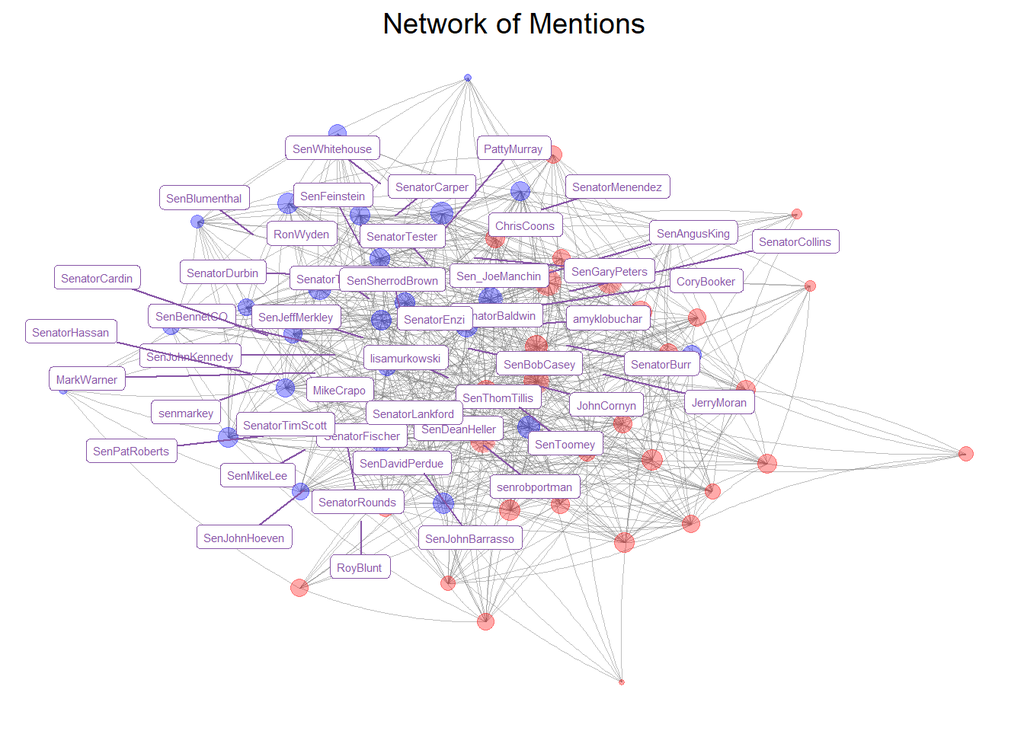

```r
#change column names
colnames(tweets_3b)[1]<-"source"
colnames(tweets_3b)[2]<-"target"

tweets_3b_gr<-graph_from_data_frame(tweets_3b[,c("source", "target")],directed=F)

V(tweets_3b_gr)$size<-centralization.degree(tweets_3b_gr)$res

#simplify
E(tweets_3b_gr)$weight <- 1
tweets_3b_g<-simplify(tweets_3b_gr, edge.attr.comb="sum")

#fortify
set.seed(2103)
data3b<-ggnetwork(tweets_3b_g, layout="fruchtermanreingold",
                arrow.gap=0, cell.jitter=0)

#edit problematic names and import party information
data3b$vertex.names<-as.character(data3b$vertex.names)
data3b$vertex.names<-replace(data3b$vertex.names,
                             data3b$vertex.names=="SenMarkey","senmarkey")
data3b$vertex.names<-replace(data3b$vertex.names,
                             data3b$vertex.names=="sendavidperdue","SenDavidPerdue")
data3b$x<-as.numeric(data3b$x)
data3b$y<-as.numeric(data3b$y)
data3b$xend<-as.numeric(data3b$xend)
data3b$yend<-as.numeric(data3b$yend)
data3b<-data3b%>%left_join(acc_aff,by = c("vertex.names"="Official.Twitter"))
data3b$Party.affiliation<-as.factor(data3b$Party.affiliation)

#draw graph
ggplot() +
  geom_edges(data=data3b,
             aes(x=x, y=y, xend=xend, yend=yend),
             color="grey50", curvature=0.1, size=0.15, alpha=1/2)+
  geom_nodes(data=data3b,
             aes(x=x, y=y, xend=xend, yend=yend,color=Party.affiliation,
                 size=sqrt(size)),
             alpha=1/3)+
  geom_label_repel(data=unique(data[data$size>120,c(1,2,5)]),
                   aes(x=x, y=y, label=vertex.names),
                   size=2, color="#8856a7")+
  theme_blank()+
  theme(legend.position="none")+
  ggtitle("Network of Mentions")+
  theme(plot.title=element_text(hjust=0.5))+
  scale_color_manual(breaks = c("Democratic Party", "Republican Party","Independent"),
                       values=c("blue","green","red"))
```

[^1]: I know they are not required, but I put them in the `html` file anyway for TAs’ better reference.
[^2]: I have to admit that this interactive plot has made display much slower.